# An Intro Into Doing Data Science Using Python

# Creating Averaged Dataframe

Because our analysis was not heavily focused on trends over time, we wanted to create a dataframe with single rows for each county that represented averaged values for that county across the five-year timespan. This will help in our analysis because now we will not have multiple entries per county and will help us focus more on underlying relationships between AQI, asthma, etc.

```python
#Merging Cancer Rates DF, renaming columns
avged_df = pd.merge(avged_df,cancer, on=['County'])
avged_df = avged_df.rename(columns={'COPD_&_Asthma_Deaths': 'COPD_and_Asthma_Deaths','Average Annual Count': 'Average_annual_cancer',
                        'Age-Adjusted Incidence Rate([rate note]) - cases per 100,000': 'Age_adjusted_cancer_rate'})

#Adding Income DF, Dropping Columns that we don't plan to use, and renaming columns.
income_df = pd.read_excel('https://raw.githubusercontent.com/ThomasJohnson35/CMSC320-datasets/main/California_Avg_Income_2019.xlsx')
avged_df = pd.merge(avged_df,income_df, on=['County'])
avged_df = avged_df[['County', 'Year', 'Num_hosp', 'Adj_hosp_rate', 'Median_aqi','Age_adjusted_cancer_rate', 'Num_hosp_adjusted_pop','Population','COPD_and_Asthma_Deaths','Average_annual_cancer','Average Income']]
avged_df = avged_df = avged_df.T.drop_duplicates().T
avged_df = avged_df.rename(columns={'Average Income': 'Average_income'})

#Adjusting datatypes of columns to floats (to make it easier to do regressions and ML)
avged_df['Age_adjusted_cancer_rate'] = avged_df['Age_adjusted_cancer_rate'].astype(float)
avged_df['Average_annual_cancer'] = avged_df['Average_annual_cancer'].astype(float)
avged_df['Num_hosp_adjusted_pop'] = avged_df['Num_hosp_adjusted_pop'].astype(float)
avged_df['Median_aqi'] = avged_df['Median_aqi'].astype(float)
avged_df['Average_income'] = avged_df['Average_income'].astype(float)
avged_df['COPD_and_Asthma_Deaths'] = avged_df['COPD_and_Asthma_Deaths'].astype(float)
avged_df['Population'] = avged_df['Population'].astype(float)
avged_df['Adjusted_COPD_and_Asthma_Deaths'] = avged_df['COPD_and_Asthma_Deaths'] / avged_df['Population']
```

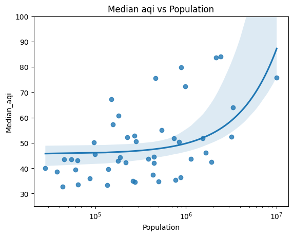

```python
#Creates a seaborn scatterplot with a regression line for the median aqi vs average population per county
aqi_vs_pop = seaborn.regplot(x=avged_df['Population'], y=avged_df['Median_aqi'])
#Because the population of certain counties is much larger than others,
#we had to set the x-axis to a logrithmic scale instead of a linear one
aqi_vs_pop.set(xscale="log")
#Sets the range of y-axis to more effectively display the plot
aqi_vs_pop.set_ylim(25, 100)
plt.title('Median aqi vs Population')
```

**As you might expect, the air quality majorly decreases with population increases. Cities that hold the most people have lots of pollution in a dense area leading to lower air quality. Los Angeles County has the highest population by far, also sporting one of the highest median aqis**

```
Below is graph of Hospitalizations versus Median AQI, Unadjusted. Each dot is a county and year combination
```

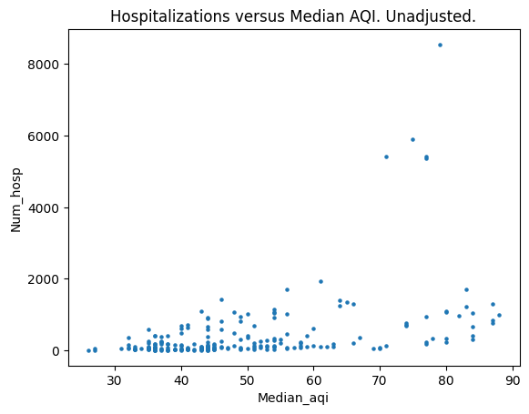

```python
#comment
plt1 = df.plot.scatter(x='Median_aqi',y='Num_hosp',s=5)
plt.title('Hospitalizations versus Median AQI. Unadjusted.')
print('Below is graph of Hospitalizations versus Median AQI, Unadjusted. Each dot is a county and year combination')
```

**Although there are some major outliers skewing this graph, Hospitalizations do seem to be correlated with higher aqi (worse air quality)**

Below is graph of Hospitalizations versus Median AQI, Adjusted for population. Each dot is a county and year combination. Some flaws in our analysis: county and year data points for hospitalizations versus AQI are not independent. The number of hospitilizations or risk of developing asthma in a given county is likely not just a factor of the pollution in that given year, but prolonged exposure (pollution in the years and decades leading up to a given year. However, we are graphing each county/year combo as a data point.

[output not shown]

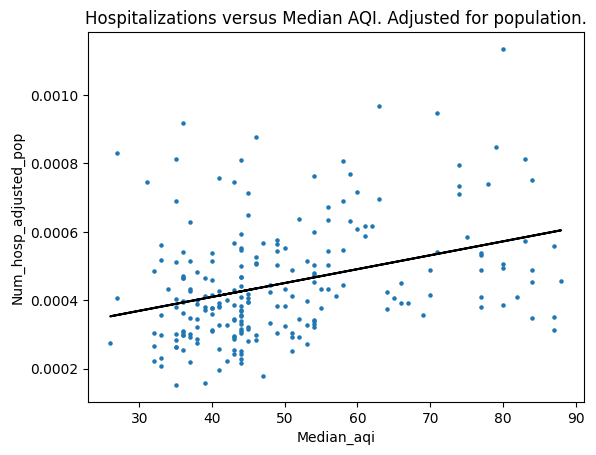

```python
#Adjusting
#comment

df['Num_hosp_adjusted_pop'] = df['Num_hosp'] / df['Population']

X = df['Median_aqi'].values.reshape(-1, 1)
y1 = df['Num_hosp_adjusted_pop'].values.reshape(-1, 1)

reg = LinearRegression().fit(X, y1)
reg.score(X,y1)

plt1 = df.plot.scatter(x='Median_aqi',y='Num_hosp_adjusted_pop',s=5)
plt.plot(X, reg.predict(X),color='k')
plt.title('Hospitalizations versus Median AQI. Adjusted for population.')
```

**As we adjusted for population in this graph the outliers are now much more subdued. This means that we can plot a linear regression on the data which shows that there is a positive correlation between Median AQI and Hospitalizations adjusted for population.**

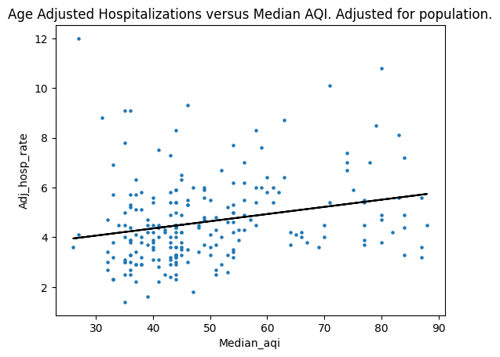

```python
X = df['Median_aqi'].values.reshape(-1, 1)
y1 = df['Adj_hosp_rate'].values.reshape(-1, 1)

reg = LinearRegression().fit(X, y1)
reg.score(X,y1)

plt1 = df.plot.scatter(x='Median_aqi',y='Adj_hosp_rate',s=5)
plt.plot(X, reg.predict(X),color='k')
plt.title('Age Adjusted Hospitalizations versus Median AQI. Adjusted for population.')
```

**There was one more confounding variable to our graph that was removable from the data we had, being age. Older people are much more likely to be hospitalized in general leading to some skews in counties with a larger elderly population. This graph shows that even adjusted for age as well there is a positive correlation betweeen AQI and Hospitalizations**

# Asthma Hospitalizations vs. AQI by County

The last part of our exploratory data anlysis included an analysis of the variations between counties in AQI levels, asthma hospitalizations, and population. The plots below show the asthma hospitalizations vs. AQI by county for each of the five years. The size of each bubble represents that county's respective population: larger bubbles have a larger population and vice versa.

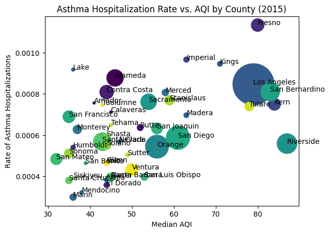

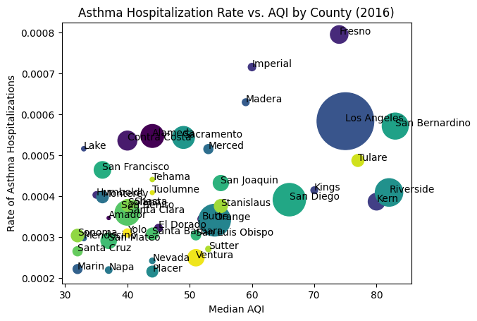

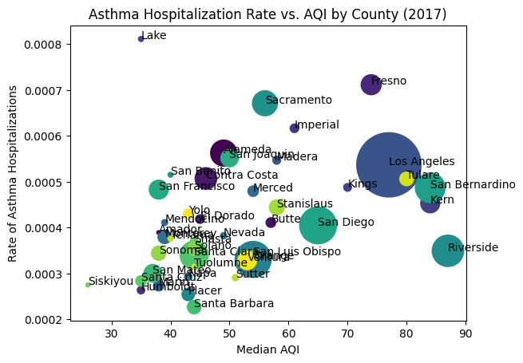

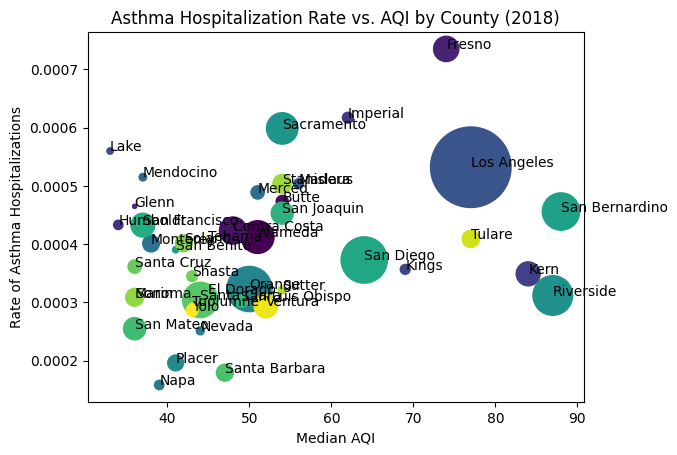

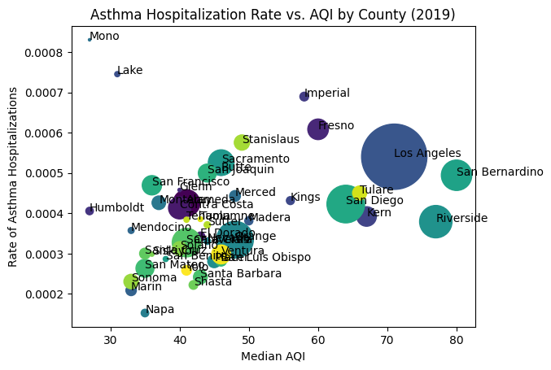

```python
grouped_df = df.groupby('Year')

# Add labels for each point with the county name
for year, group in grouped_df:
    plt.scatter(group['Median_aqi'], group['Num_hosp_adjusted_pop'], s=group['Population']/3000, c=range(len(group)), cmap='viridis')
    for i, row in group.iterrows():
        plt.annotate(row['County'], xy=(row['Median_aqi'], row['Num_hosp_adjusted_pop']))
    plt.xlabel('Median AQI')
    plt.ylabel('Rate of Asthma Hospitalizations')
    plt.title(f'Asthma Hospitalization Rate vs. AQI by County ({year})')
    plt.show()
```

We can clearly see a somewhat linear relationship over the years, as well as counties with high populationssuch as Los Angeles and San Diego tending to have higher AQIs and thus higher hospitalization rates.

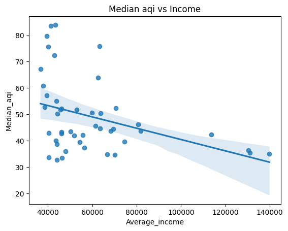

```python
#Creates another seaborn scatterplot with a linear regression, for median aqi vs average income
aqi_vs_pop = seaborn.regplot(x=avged_df['Average_income'], y=avged_df['Median_aqi'])
plt.title('Median aqi vs Income')
```

**We expected that higher income areas would be the cities with the largest populations, leading to more air pollution. This turned out to be the exact opposite, as the richer the area was, the better air quality they had**

# Hypothesis Testing / ML

## Ordinary Least Squares Regressions for Asthma Hospitalizations

Using statsmodels, we run an Ordinary Least Squares (OLS) regression for Asthma Hospitalizations (rate adjusted for county populations), with respect to median air quality index. Examining the printed regression results, we can see that our R-squared is relatively low, at .193. Our p-value for median air quality with respect to our dependent variable, asthma hospitalizations, is .002. A p-value measures the probability that our variable's impact occurs via random chance. Generally, if a p-value is less then 0.05, we can conclude that our variables impact is likely statistically significant. Therefore, we reject the null hypothesis, and we can conclude that air quality is statistically significant for asthma hospitilizations.

Next, we run an OLS regression for Asthma Hospitalizations (rate adjusted for county populations) with respect to average income. The p-value of average income is 0.010, which also allows us to reject the null hypothesis and conclude that the average income of a given county is statistically significant for asthma hospitilizations in that county. Important to note that our r-values are relatively low for both of these models. This does not mean our models are incorrect or flawed, but rather that they are incomplete --- while our p-values tell us our predictors are significant, there are more predictors that we are not considering that are necessary to have a complete model. This makes sense, as health metrics in real life are complicated -- there are many more factors that go into health than just income and air quality.

For help with understanding the OLS Regression Results Summary, you can read more here https://medium.com/swlh/interpreting-linear-regression-through-statsmodels-summary-4796d359035a

```python
mod = smf.ols(formula='Num_hosp_adjusted_pop ~ Median_aqi', data=avged_df)
res = mod.fit()
print(res.summary())
#OLS regression for number of hospitilizations for asthma (adjusted by populatiom) and median AQI. P value for median aqi is .002,
#which we can confidently reject our null hypothesis (Air Quality is statistically significant for asthma hospitilizations)
#https://patsy.readthedocs.io/en/latest/formulas.html#the-formula-language Statsmodel

mod = smf.ols(formula='Num_hosp_adjusted_pop ~ Average_income', data=avged_df)
res = mod.fit()
print(res.summary())
#OLS regression for number of hospitilizations for asthma (adjusted by populatiom) and income, p value for average_income is .01,
#which we can confidently reject our null hypothesis (Income is statistically significant for asthma hospitilizations)
```

```
                              OLS Regression Results
=================================================================================
Dep. Variable:     Num_hosp_adjusted_pop   R-squared:                       0.193
Model:                               OLS   Adj. R-squared:                  0.175
Method:                    Least Squares   F-statistic:                     10.53
Date:                   Sat, 13 May 2023   Prob (F-statistic):            0.00225
Time:                           03:14:12   Log-Likelihood:                 353.40
No. Observations:                     46   AIC:                            -702.8
Df Residuals:                         44   BIC:                            -699.1
Df Model:                              1
Covariance Type:               nonrobust
==============================================================================
                 coef    std err          t      P>|t|      [0.025      0.975]
------------------------------------------------------------------------------
Intercept      0.0003   6.16e-05      4.132      0.000       0.000       0.000
Median_aqi  3.908e-06    1.2e-06      3.245      0.002    1.48e-06    6.33e-06
==============================================================================
Omnibus:                        5.511   Durbin-Watson:                   1.741
Prob(Omnibus):                  0.064   Jarque-Bera (JB):                4.442
Skew:                           0.731   Prob(JB):                        0.108
Kurtosis:                       3.427   Cond. No.                         187.
==============================================================================

Notes:
[1] Standard Errors assume that the covariance matrix of the errors is correctly specified.
                              OLS Regression Results
=================================================================================
Dep. Variable:     Num_hosp_adjusted_pop   R-squared:                       0.142
Model:                               OLS   Adj. R-squared:                  0.123
Method:                    Least Squares   F-statistic:                     7.294
Date:                   Sat, 13 May 2023   Prob (F-statistic):            0.00979
Time:                           03:14:12   Log-Likelihood:                 351.99
No. Observations:                     46   AIC:                            -700.0
Df Residuals:                         44   BIC:                            -696.3
Df Model:                              1
Covariance Type:               nonrobust
==================================================================================
                     coef    std err          t      P>|t|      [0.025      0.975]
----------------------------------------------------------------------------------
Intercept          0.0006   4.52e-05     12.374      0.000       0.000       0.001
Average_income -1.899e-09   7.03e-10     -2.701      0.010   -3.32e-09   -4.82e-10
==============================================================================
Omnibus:                        4.793   Durbin-Watson:                   1.752
Prob(Omnibus):                  0.091   Jarque-Bera (JB):                4.199
Skew:                           0.740   Prob(JB):                        0.122
Kurtosis:                       3.036   Cond. No.                     1.68e+05
==============================================================================

Notes:
[1] Standard Errors assume that the covariance matrix of the errors is correctly specified.
[2] The condition number is large, 1.68e+05. This might indicate that there are
strong multicollinearity or other numerical problems.
```

## Ordinary Least Squares Regressions for Cancer Rates

Running an Ordinary Least Squares (OLS) regression for Cancer Rates (rate adjusted for county populations), with respect to median air quality index, we find an extremely low r-squared for our model, and a p-value of .149 for median air quality. Given this, we can say that air quality alone is not a statistically significant predictor of cancer rates for a given county, and we cannot reject the null hypothesis.

However, running an OLS regression for Cancer Rates with respect to average income gives us a significantly better result. While our model is still relatively incomplete, our p-value of .003 tells us that income is a statistically significant predictor of cancer (the higher the income, the lower the cancer rate).

```python
mod = smf.ols(formula='Age_adjusted_cancer_rate ~ Median_aqi', data=avged_df)
res = mod.fit()
print(res.summary())
#OLS regression for number of hospitilizations for cancer (adjusted by populatiom) and median AQI. P value for median aqi is .149,
#which is too high to confidently reject our null hypothesis. (We cannot conclude Income is statistically significant for cancer rates)

mod = smf.ols(formula='Age_adjusted_cancer_rate ~ Average_income', data=avged_df)
res = mod.fit()
print(res.summary())
#OLS regression for number of hospitilizations for asthma (adjusted by populatiom) and average income. P value is .003,
#So we can confidently reject our null hypothesis. (Income is statistically significant for cancer rates)
```

```
                               OLS Regression Results
====================================================================================
Dep. Variable:     Age_adjusted_cancer_rate   R-squared:                       0.047
Model:                                  OLS   Adj. R-squared:                  0.025
Method:                       Least Squares   F-statistic:                     2.157
Date:                      Sat, 13 May 2023   Prob (F-statistic):              0.149
Time:                              03:14:12   Log-Likelihood:                -157.27
No. Observations:                        46   AIC:                             318.5
Df Residuals:                            44   BIC:                             322.2
Df Model:                                 1
Covariance Type:                  nonrobust
==============================================================================
                 coef    std err          t      P>|t|      [0.025      0.975]
------------------------------------------------------------------------------
Intercept     48.7068      4.079     11.939      0.000      40.485      56.929
Median_aqi    -0.1172      0.080     -1.469      0.149      -0.278       0.044
==============================================================================
Omnibus:                        4.430   Durbin-Watson:                   1.860
Prob(Omnibus):                  0.109   Jarque-Bera (JB):                3.636
Skew:                           0.684   Prob(JB):                        0.162
Kurtosis:                       3.165   Cond. No.                         187.
==============================================================================

Notes:
[1] Standard Errors assume that the covariance matrix of the errors is correctly specified.
                               OLS Regression Results
====================================================================================
Dep. Variable:     Age_adjusted_cancer_rate   R-squared:                       0.179
Model:                                  OLS   Adj. R-squared:                  0.160
Method:                       Least Squares   F-statistic:                     9.576
Date:                      Sat, 13 May 2023   Prob (F-statistic):            0.00342
Time:                              03:14:12   Log-Likelihood:                -153.84
No. Observations:                        46   AIC:                             311.7
Df Residuals:                            44   BIC:                             315.3
Df Model:                                 1
Covariance Type:                  nonrobust
==================================================================================
                     coef    std err          t      P>|t|      [0.025      0.975]
----------------------------------------------------------------------------------
Intercept         50.6500      2.697     18.784      0.000      45.216      56.084
Average_income    -0.0001   4.19e-05     -3.094      0.003      -0.000   -4.53e-05
==============================================================================
Omnibus:                        5.573   Durbin-Watson:                   2.234
Prob(Omnibus):                  0.062   Jarque-Bera (JB):                4.395
Skew:                           0.702   Prob(JB):                        0.111
Kurtosis:                       3.568   Cond. No.                     1.68e+05
==============================================================================

Notes:
[1] Standard Errors assume that the covariance matrix of the errors is correctly specified.
[2] The condition number is large, 1.68e+05. This might indicate that there are
strong multicollinearity or other numerical problems.
```

```python
mod = smf.ols(formula='Adjusted_COPD_and_Asthma_Deaths ~ Median_aqi', data=avged_df)
res = mod.fit()
print(res.summary())
#OLS regression for number of hospitilizations for COPD and Asthma Deaths


mod = smf.ols(formula='Adjusted_COPD_and_Asthma_Deaths ~ Average_income', data=avged_df)
res = mod.fit()
print(res.summary())
#OLS regression for number of hospitilizations for asthma (adjusted by populatiom) and median AQI. P value for median aqi is .002,
#which we can confidently reject our null hypothesis
```

```
                                   OLS Regression Results
===========================================================================================
Dep. Variable:     Adjusted_COPD_and_Asthma_Deaths   R-squared:                       0.132
Model:                                         OLS   Adj. R-squared:                  0.112
Method:                              Least Squares   F-statistic:                     6.686
Date:                             Sat, 13 May 2023   Prob (F-statistic):             0.0131
Time:                                     03:14:12   Log-Likelihood:                 265.70
No. Observations:                               46   AIC:                            -527.4
Df Residuals:                                   44   BIC:                            -523.7
Df Model:                                        1
Covariance Type:                         nonrobust
==============================================================================
                 coef    std err          t      P>|t|      [0.025      0.975]
------------------------------------------------------------------------------
Intercept      0.0022      0.000      5.203      0.000       0.001       0.003
Median_aqi -2.096e-05    8.1e-06     -2.586      0.013   -3.73e-05   -4.62e-06
==============================================================================
Omnibus:                       15.079   Durbin-Watson:                   1.663
Prob(Omnibus):                  0.001   Jarque-Bera (JB):               17.039
Skew:                           1.227   Prob(JB):                     0.000200
Kurtosis:                       4.693   Cond. No.                         187.
==============================================================================

Notes:
[1] Standard Errors assume that the covariance matrix of the errors is correctly specified.
                                   OLS Regression Results
===========================================================================================
Dep. Variable:     Adjusted_COPD_and_Asthma_Deaths   R-squared:                       0.157
Model:                                         OLS   Adj. R-squared:                  0.138
Method:                              Least Squares   F-statistic:                     8.213
Date:                             Sat, 13 May 2023   Prob (F-statistic):            0.00636
Time:                                     03:14:12   Log-Likelihood:                 266.38
No. Observations:                               46   AIC:                            -528.8
Df Residuals:                                   44   BIC:                            -525.1
Df Model:                                        1
Covariance Type:                         nonrobust
==================================================================================
                     coef    std err          t      P>|t|      [0.025      0.975]
----------------------------------------------------------------------------------
Intercept          0.0019      0.000      6.517      0.000       0.001       0.002
Average_income -1.296e-08   4.52e-09     -2.866      0.006   -2.21e-08   -3.85e-09
==============================================================================
Omnibus:                       14.551   Durbin-Watson:                   2.098
Prob(Omnibus):                  0.001   Jarque-Bera (JB):               16.919
Skew:                           1.133   Prob(JB):                     0.000212
Kurtosis:                       4.922   Cond. No.                     1.68e+05
==============================================================================

Notes:
[1] Standard Errors assume that the covariance matrix of the errors is correctly specified.
[2] The condition number is large, 1.68e+05. This might indicate that there are
strong multicollinearity or other numerical problems.
```

# Conclusion

Building predictive models for health conditions is an extremely complicated pursuit. Unfortunately, given the scope of this class and project, we are unable to finish accurate predictive models for health conditions.

However, we were able to show and explain each step of the data science pipeline. We scraped, curated, parsed and cleaned our data sets from different government sites to get dataframes that were easy to work with that contained our predictive factors (air quality and income) and health conditions (cancer rates, asthma hospitilizations, and COPD and asthma deaths).

Our exploratory data analysis showed some basic correlations between much of our data, and we were able to showcase our data visualization through our graphs.

Finally, our hypothesis testing and regression algorithims told us some interesting things about our data. It confirmed that our models were incomplete, as we were missing predictive factors, but we were able to draw conclusions about certain combinations of health conditions and predictive factors (e.g. income and cancer rates are predictive, air quality and asthma is predictive, but cancer and air quality is not conclusively predictive).